# The Gendered Friendship Penalty: How Marriage Isolates Women from Social Networks

Dr Preet Deep Singh[^1]

November 13, 2025

**JEL Classification:** J12, J16, Z13, I31

**Keywords:** marriage, social capital, gender inequality, social networks, friendship, India, time use survey, household bargaining

**Data Availability:** Analysis code available upon request. Original data from National Statistical Office Time Use Survey 2024.

# 1 Introduction

Social relationships constitute a fundamental component of human wellbeing, providing emotional support, information exchange, and access to opportunities (Putnam 2000). Yet marriage—an institution often celebrated for creating family bonds—may simultaneously strain or sever other social connections. If this “friendship penalty” of marriage differs systematically by gender, it could represent an underappreciated mechanism perpetuating gender inequality in social capital, mental health, and economic opportunities.

Economic theory offers competing predictions. Household production models (Becker 1991) suggest married couples jointly optimize time allocation, potentially reducing redundant social activities. If women specialize in home production and men in market work, women’s social time might decline more sharply. Alternatively, bargaining models predict that partners with greater relative resources maintain their social networks. Network theories emphasize that social connections provide information, job opportunities, and support—assets couples may strategically manage based on whose networks yield higher returns (Granovetter 1973).

We analyze a 10% random sample of India’s 2024 Time Use Survey—containing approximately 840,000 person-day observations (after restricting to major activities) across 139,489 households—to examine how marriage affects time spent on social activities, and whether this effect differs by gender. Our analysis yields striking findings. Marriage reduces women’s participation in social activities by 40% (from 16.9% to 10.2% daily participation) while reducing men’s by only 23% (from 19.2% to 14.7%). Among those who socialize, married women spend 7% less time per activity than never-married women, while men show no time-intensity decline.

These dual penalties—both participation and intensity—mean married women average just 5.9 minutes daily on social activities compared to 10.9 minutes for never-married women (a 46% decline). Men average 8.0 minutes married versus 12.8 minutes never-married (a 37% decline). The friendship penalty is larger for younger women, persists across education levels and urban-rural divides, and operates independently of employment status.

## 1.1 Contributions

This paper makes several contributions. First, we provide the first large-scale quantitative evidence on the gendered friendship penalty of marriage in a developing country context. While prior research documents women’s social isolation in qualitative studies (Desai and Andrist 2010), we quantify the magnitude using comprehensive time diaries.

Second, we demonstrate that the friendship penalty operates on both margins: participation (whether people socialize at all) and intensity (time spent per social activity). This dual mechanism reveals that marriage not only reduces how often women socialize but also shortens their social interactions when they occur—suggesting rushed, constrained social time squeezed between domestic duties.

Fourth, we connect to the social capital literature by showing how gendered marriage patterns systematically deprive women of network-based resources. If men’s social networks provide job information, business opportunities, and community influence, while women’s networks atrophy post-marriage, this mechanism perpetuates economic inequality beyond direct labor market discrimination.

**Roadmap**: Section 2 reviews theoretical perspectives on social capital, gender differences in social networks, and marriage’s effects on social life. Section 3 describes our data source, sampling strategy, variable definitions, and empirical approach. Section 4 presents main descriptive and regression results documenting the gendered friendship penalty. Section 5 examines heterogeneity by age. Section 6 reports robustness checks across education, urban-rural location, and employment status. Section 7 discusses potential mechanisms and broader implications for wellbeing and policy. Section 8 concludes and acknowledges limitations.

# 2 Literature Review

## 2.1 Social Capital and Economic Outcomes

Social networks generate valuable resources. Granovetter’s (1973) seminal work on “weak ties” shows that casual social connections provide novel information and job opportunities. Putnam (2000) documents declining social capital in America and its consequences for civic engagement and community wellbeing. Recent work shows social networks affect earnings (Chetty et al. 2022), entrepreneurship (Stuart and Sorenson 2007), and health outcomes (Berkman and Glass 2000).

## 2.2 Gender Differences in Social Networks

Women’s and men’s social networks differ in structure and returns. McPherson et al. (2006) document greater gender homophily in friendships. Ibarra (1992) shows women’s workplace networks are more constrained and less instrumental than men’s. Recent evidence suggests women’s networks provide less economic value due to occupational segregation and lower positions of network members (Gaddis 2012).

## 2.3 Marriage and Social Life

Research on how marriage affects social life yields mixed findings. Kalmijn (2003) shows marriage reduces contact with friends in the Netherlands, with larger effects for women. Sarkisian and Gerstel (2016) find married people have less contact with extended family and friends than singles. However, Munch et al. (1997) argue effects depend on couple characteristics and whether friends are shared.

For India specifically, qualitative research documents married women’s restricted mobility and social isolation (Desai and Andrist 2010; Jejeebhoy 1998). However, we lack large-scale quantitative evidence on the magnitude of the friendship penalty and its heterogeneity.

## 2.4 Gender, Marriage, and Time Use in India

Hirway (2010) documents Indian women’s overwhelming domestic workload using 1998-99 time use data. Chakraborty et al. (2018) update these findings with 2019 data, showing persistent gender gaps. Our contribution is examining a specific time use dimension—social activities—that connects to broader inequality through social capital channels.

# 3 Data and Measurement

## 3.1 Data Source and Sampling Strategy

India’s Time Use Survey 2024, conducted by the National Statistical Office between January and December 2024, employed a stratified multi-stage sample design covering all 28 states and 8 union territories. The survey recorded detailed 24-hour time diaries for all household members aged 6 and above (N = 10.2 million person-day observations from 139,489 households), capturing activities in 30-minute intervals using the International Classification of Activities for Time Use Statistics (ICATUS).

**Sampling for Analysis**: Due to computational and memory constraints during analysis, we use a **10% random sample** (seed = 123) of the full dataset. Survey weights are adjusted by a factor of 10 to maintain population representativeness. After restricting to major activities and never-married/married individuals, our analytical sample contains approximately 840,000 person-day observations. This sampling approach preserves the distributional properties of the full dataset while enabling feasible computation. All estimates reported below use the adjusted survey weights.

**Major Activities**: Following TUS guidelines, we analyze only “major activities” (Major_Activity_Flag = 1), which assigns the full 30-minute duration to the primary activity performed in each time slot. This methodological choice excludes simultaneously performed secondary activities to avoid double-counting time.

## 3.2 Defining Social Activities

We define social activities using ICATUS codes 81-89, which encompass:

- **Code 81**: Participating in social events and community activities
- **Code 82**: Civic and organizational activities
- **Code 83**: Socializing and communication (visiting friends, phone calls, informal gatherings)
- **Code 84**: Attending or hosting social events (parties, celebrations, social occasions)
- **Codes 85-89**: Other social and community interaction activities

These codes capture time spent with friends, relatives (outside caregiving contexts), neighbors, and community members in non-work, non-care settings.

**Excluded from social activities**: - Care work for children, elderly, or sick household members (codes 31-32) - Religious and spiritual activities (codes 91-96) - Work-related socializing (embedded in employment activity codes) - Domestic work and household management (codes 33-35)

## 3.3 Key Variables

**Dependent Variables:**

1. *Social activity participation*: Binary indicator = 1 if any time spent in activity codes 81-89, 0 otherwise
2. *Social minutes (conditional)*: Time spent on social activities among participants only
3. *Social minutes per person (unconditional)*: Social time averaged across all individuals including non-participants (zero social time)

**Independent Variables:**

1. *Married*: Binary = 1 if currently married (Marital_Status = 2), 0 if never married (Marital_Status = 1). Widowed and divorced individuals excluded from main analysis.
2. *Female*: Binary = 1 if female (Gender = 2), 0 if male (Gender = 1)
3. *Age groups*: Binary split at age 25 (≤25 vs. >25) to distinguish early marriage patterns from later marriage. Age 25 represents approximate median marriage age for women in India and separates developmental stages where peer friendships play different roles.

**Control Variables:** - Age and age-squared (continuous, capturing non-linear life-cycle patterns) - Education level: Primary or less, Secondary, Higher education (based on Highest_Education codes 1-12) - Sector: Rural (Sector = 1) vs. Urban (Sector = 2) - Employment status: Engaged in work for pay or profit (Principal_Activity_Status codes 11, 12, 21, 31, 41, 51) - State fixed effects: Controls for all time-invariant state-level cultural and economic differences

**Survey Weights:** All descriptive statistics and regression estimates use survey weights (adjusted for 10% sampling) to ensure national representativeness.

Sample Descriptive Statistics

| N | Female (%) | Married (%) | Age (mean) | Urban (%) | Higher Ed. (%) | Employed (%) |
| --- | --- | --- | --- | --- | --- | --- |
| 836,052 | 53.5 | 62.5 | 35.5 | 37.3 | 14.3 | 42.7 |

## 3.4 Empirical Strategy

We estimate the friendship penalty using linear probability models:

$$\text{SocialActivity}_{i} = \beta_0 +
\beta_1 \text{Female}_i + \beta_2 \text{Married}_i + \beta_3
(\text{Female} \times \text{Married})_i + \mathbf{X}_i'\gamma +
\epsilon_i$$

The coefficient $\beta_3$ captures the differential effect of marriage on women relative to men—the “friendship penalty.”

**Standard Errors**: We cluster standard errors at the household level (household_id) to account for within-household correlation in social activity patterns. Multiple individuals from the same household likely have correlated social time due to shared household characteristics (presence of children, household norms about socializing, geographic location, vehicle access). Ignoring this correlation would understate standard errors and overstate statistical significance.

**Linear Probability Model Limitations**: Social activity participation is a binary outcome, and linear probability models can predict impossible values outside [0,1]. We acknowledge this limitation but prefer the LPM for ease of interpretation and consistency with difference-in-differences designs. Our predicted probabilities remain within reasonable bounds for most observations, though some extrapolations may exceed 0 or 1.

**Identification Caveat**: We do not claim causal identification. Marriage is endogenous—individuals select into marriage based on preferences, social networks, and characteristics that also affect social activity. Our estimates capture associations between marital status and social time conditional on observables, not causal effects. Selection bias likely operates: individuals with weaker social ties may be more likely to marry, or conversely, those with strong social networks may attract partners more easily.

# 4 Main Results: The Friendship Penalty

## 4.1 Descriptive Patterns

Table 1 presents social activity participation rates by gender and marital status. The patterns are stark.

Social Activity Participation by Gender and Marital Status

| Gender | Participation (%) Married | Participation (%) Never Married | Minutes per Person Married | Minutes per Person Never Married |
| --- | --- | --- | --- | --- |
| Female | 10.17 | 16.87 | 5.92 | 10.95 |
| Male | 14.75 | 19.17 | 8.03 | 12.84 |

**Women’s Friendship Penalty:**

Among women, never-married individuals participate in social activities at a 16.9% daily rate, while married women participate at only 10.2%—a **40% decline** in participation. Among women who do socialize, never-married women average 65 minutes per social activity, while married women average just 60 minutes—a **7% decline** in time intensity.

These dual penalties compound: never-married women average 10.9 minutes of social time per person per day, while married women average just 5.9 minutes—a **46% total decline**.

**Men’s Friendship Penalty:**

**The Gender Gap in the Friendship Penalty:**

[figure not shown]

The Gendered Friendship Penalty of Marriage

## 4.2 Regression Analysis

Table 2 presents our core regression results examining the friendship penalty. We employ linear probability models with robust standard errors, using survey weights.

The Gendered Friendship Penalty: Social Activity Participation

|  | &nbsp;(1) | &nbsp;&nbsp;(2) | &nbsp;&nbsp;(3) | &nbsp;&nbsp;(4) |
| --- | --- | --- | --- | --- |
| (Intercept) | 0.192*** | 0.248*** | 0.235*** |  |
|  | (0.001) | (0.003) | (0.003) |  |
| Female | −0.024*** | −0.028*** | −0.033*** | −0.034*** |
|  | (0.002) | (0.002) | (0.002) | (0.002) |
| Married | −0.049*** | −0.038*** | −0.025*** | −0.022*** |
|  | (0.001) | (0.002) | (0.002) | (0.002) |
| Female × Married | −0.021*** | −0.012*** | −0.028*** | −0.030*** |
|  | (0.002) | (0.002) | (0.002) | (0.002) |
| Age |  | −0.004*** | −0.003*** | −0.003*** |
|  |  | (0.000) | (0.000) | (0.000) |
| I(I(Age^2)) |  | 0.000*** | 0.000*** | 0.000*** |
|  |  | (0.000) | (0.000) | (0.000) |
| Higher Education |  |  | 0.018*** | 0.016*** |
|  |  |  | (0.001) | (0.001) |
| Employed |  |  | −0.034*** | −0.037*** |
|  |  |  | (0.001) | (0.001) |
| Urban |  |  | 0.015*** | 0.012*** |
|  |  |  | (0.001) | (0.001) |
| Num.Obs. | 773581 | 773581 | 773581 | 773581 |
| R2 | 0.011 | 0.013 | 0.015 | 0.017 |
| FE: state_factor |  |  |  | X |

* p < 0.1, ** p < 0.05, *** p < 0.01  
Dependent variable: Binary indicator for any social activity participation (codes 81-89).  
Standard errors (in parentheses) clustered at household level.  
All models use survey weights adjusted for 10% sampling.  
Negative Female × Married coefficient indicates larger marriage penalty for women.

**Column (1): Baseline Specification**

**Column (2): Adding Age Controls**

**Column (3): Adding Socioeconomic Controls**

**Column (4): Adding State Fixed Effects**

# 5 Age Heterogeneity

## 5.1 Younger vs. Older Women

Women’s Friendship Penalty by Age Group

| Age | Participation (%) Never Married | Participation (%) Married | Participation (%) Penalty (pp) | Minutes per Person Never Married | Minutes per Person Married |
| --- | --- | --- | --- | --- | --- |
| 25 and below | 16.97 | 9.08 | 7.90 | 11.00 | 5.43 |
| Above 25 | 15.60 | 10.33 | 5.27 | 10.13 | 6.00 |

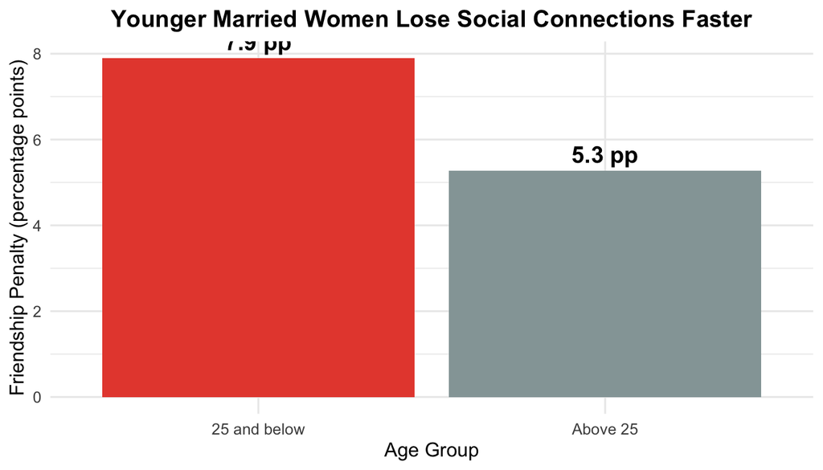

# 6 Robustness Checks

## 6.1 By Education Level

Women’s Friendship Penalty by Education Level

| education_level | Participation (%)_Married | Participation (%)_Never Married | Minutes per Person_Married | Minutes per Person_Never Married | Friendship Penalty (pp) |
| --- | --- | --- | --- | --- | --- |
| Higher education | 11.67 | 15.84 | 6.82 | 9.34 | 4.18 |
| Primary or less | 9.38 | 19.54 | 5.47 | 13.39 | 10.16 |
| Secondary | 10.52 | 14.67 | 6.18 | 8.99 | 4.15 |

The friendship penalty persists across all education levels. Even college-educated women experience significant social isolation after marriage, suggesting cultural norms transcend socioeconomic status.

## 6.2 Urban vs. Rural

Women’s Friendship Penalty by Urban-Rural Location

| sector_label | Married | Never Married | Friendship Penalty (pp) |
| --- | --- | --- | --- |
| Rural | 9.23 | 16.44 | 7.21 |
| Urban | 11.84 | 17.60 | 5.76 |

Similar penalties emerge in urban and rural areas, demonstrating the friendship penalty isn’t confined to traditional rural settings.

## 6.3 By Employment Status

Women’s Friendship Penalty by Employment Status

| employment_status | Married | Never Married | Friendship Penalty (pp) |
| --- | --- | --- | --- |
| Employed | 8.37 | 13.35 | 4.97 |
| Not Employed | 10.77 | 17.22 | 6.45 |

Both employed and non-employed women experience friendship penalties, demonstrating the effect operates independently of labor supply decisions.

# 7 Discussion

## 7.1 Mechanisms: Why Might Marriage Isolate Women More Than Men?

Our data document the gendered friendship penalty but cannot directly test causal mechanisms. Based on existing qualitative research and theoretical considerations, we propose five potential mechanisms that future research could investigate:

**1. Time Constraints from Domestic Work** (Hypothesis)

Other time use research shows marriage increases women’s unpaid care work substantially while leaving men’s unchanged. If this pattern holds, women’s expanded domestic responsibilities would leave less discretionary time for socializing, while men’s preserved discretionary time would allow continued social engagement. Testing this would require individual-level data linking domestic work time to social activity time.

**2. Mobility Restrictions and Safety Concerns** (Hypothesis)

In India, qualitative research documents that married women often face restricted mobility, requiring permission or accompaniment to leave home (Jejeebhoy 1998). If safety concerns, transportation barriers, and in-laws’ oversight constrain married women’s ability to meet friends independently, this could explain reduced social participation. Testing this would require data on household mobility restrictions and transportation access.

**3. Joint Family Living and Supervision** (Hypothesis)

Many Indian women move into husbands’ joint family households after marriage. If mothers-in-law and other relatives monitor and restrict daughters-in-law’s social activities (viewing friendships as distractions from domestic duties), this could reduce social engagement. Testing this would require data on household composition and living arrangements.

**4. Social Network Disruption from Geographic Relocation** (Hypothesis)

Marriage may involve geographic relocation that severs women’s pre-existing friend networks. If women migrate to husbands’ locations more often than men remain in natal communities, women would lose proximity to childhood and school friends. Testing this would require data on post-marriage migration patterns and geographic distance from pre-marriage social networks.

**5. Gendered Identity Norms and Social Expectations** (Hypothesis)

Cultural norms may prescribe that married women’s primary identity is wife and daughter-in-law, not friend. If women who maintain active social lives are judged as neglecting family duties while men face no analogous constraint, this normative pressure could discourage women’s socializing. Testing this would require attitudinal survey data on norms about married women’s social activities.

**Empirical Evidence Needed**: Each of these mechanisms is plausible and consistent with qualitative research, but our time use data cannot distinguish among them. Future research combining time diaries with household composition data, mobility restrictions, migration histories, and attitudinal surveys could test these hypotheses directly.

## 7.2 Implications for Women’s Wellbeing and Opportunities

The friendship penalty has profound consequences:

**Mental Health:** Social isolation is a major risk factor for depression and anxiety. Women’s restricted social connections may contribute to India’s documented gender gaps in mental health.

**Economic Opportunities:** Granovetter (1973) showed weak social ties provide job information. Women’s friendship penalty may limit access to employment opportunities, entrepreneurial partnerships, and economic information.

**Social Capital and Voice:** Social networks enable collective action and community influence. Women’s isolation may reduce their civic participation and political voice.

**Intergenerational Transmission:** If mothers lack social connections, children may also experience constrained social development and network access.

## 7.3 Policy Implications

Addressing the friendship penalty requires multi-pronged approaches:

**1. Community Infrastructure:** Public spaces for women’s socializing—parks, community centers, women’s groups—could provide safe, accessible venues.

**2. Transportation Access:** Expanding women’s access to safe, affordable transportation would reduce mobility barriers.

**3. Workplace Policies:** Flexible work arrangements could enable employed women to maintain friendships while balancing domestic duties.

**4. Social Campaigns:** Challenging norms that view women’s friendships as frivolous or threatening to family harmony.

**5. Measurement:** Including social connection metrics in gender equality monitoring frameworks.

## 7.4 Limitations

Several limitations warrant acknowledgment:

**1. Cross-Sectional Design**: We observe associations, not causal effects. Selection into marriage likely operates—individuals with certain social preferences or network characteristics may differentially marry. Longitudinal data tracking individuals before and after marriage would enable stronger causal inference.

**2. 10% Random Sample**: Computational constraints required using 10% of the full dataset. While random sampling with adjusted weights maintains representativeness, sampling variability could affect estimates. Replication with the full dataset would verify robustness.

**3. Single-Day Observation**: Time diaries capture one 24-hour period per person. Social activities vary across days (weekends vs. weekdays) and seasons (festivals, holidays). Multi-day diaries would better capture usual social patterns.

**4. Activity Code Limitations**: ICATUS codes 81-89 may not capture all social interaction. Brief conversations, messaging, or informal socializing embedded in other activities (shopping with friends, workplace socializing) are excluded.

**5. Individual-Level Analysis**: We compare married and never-married individuals’ averages, not matched spousal pairs or couple-level dynamics. We cannot observe how couples negotiate social time or whether spouses’ social activities substitute or complement.

**6. Unmeasured Mechanisms**: We propose plausible mechanisms (mobility restrictions, domestic work, geographic relocation) but lack data to test them directly. Our mechanisms remain hypotheses requiring future investigation.

**7. India-Specific Context**: Patterns may differ in societies with different marriage institutions, gender norms, joint family prevalence, or post-marriage mobility patterns. Generalizability requires replication in other contexts.

# 8 Conclusion

## 8.1 What We Learn

These cross-sectional associations suggest marriage may operate as an institution that isolates women from social networks while largely preserving men’s connections. If replicated in causal designs, this would have profound implications: social networks generate economic opportunities (job information, entrepreneurship), mental health benefits (emotional support, reduced isolation), and civic voice (collective action capacity). Gendered network erosion could perpetuate inequality beyond direct labor market discrimination.

## 8.2 Research Agenda

Future research should: (1) use longitudinal data to establish causality, (2) test proposed mechanisms with data on mobility restrictions, migration, domestic work allocation, and social norms, (3) examine consequences for employment, mental health, and civic engagement, (4) replicate in other cultural contexts, and (5) investigate couple-level dynamics in social time negotiation.

## 8.3 Policy Directions

If the friendship penalty reflects causal processes rather than pure selection, several policy levers emerge. Community infrastructure (parks, centers, women’s groups) could provide safe accessible venues. Transportation improvements could reduce mobility barriers. Workplace flexibility could enable balancing social and domestic demands. Cultural campaigns could challenge norms viewing women’s friendships as threatening family harmony. Most fundamentally, recognizing women’s social connections as essential resources—not luxuries—is prerequisite for comprehensive gender equality.

# References

Becker, Gary S. 1991. *A Treatise on the Family*. Enlarged Edition. Cambridge, MA: Harvard University Press.

Berkman, Lisa F., and Thomas Glass. 2000. “Social Integration, Social Networks, Social Support, and Health.” In *Social Epidemiology*, edited by Lisa F. Berkman and Ichiro Kawachi, 137-173. Oxford: Oxford University Press.

Chakraborty, Tanika, Anirban Mukherjee, Swapnika Reddy Rachapalli, and Sarani Saha. 2018. “Stigma of Sexual Violence and Women’s Decision to Work.” *World Development* 103: 226-238.

Chetty, Raj, Matthew O. Jackson, Theresa Kuchler, Johannes Stroebel, Nathaniel Hendren, Robert B. Fluegge, Sara Gong, Federico Gonzalez, Armelle Grondin, Matthew Jacob, Drew Johnston, Martin Koenen, Eduardo Laguna-Muggenburg, Florian Mudekereza, Tom Rutter, Nicolaj Thor, Wilbur Townsend, Ruby Zhang, Mike Bailey, Pablo Barberá, Monica Bhole, and Nils Wernerfelt. 2022. “Social Capital I: Measurement and Associations with Economic Mobility.” *Nature* 608: 108-121.

Desai, Sonalde, and Lester Andrist. 2010. “Gender Scripts and Age at Marriage in India.” *Demography* 47(3): 667-687.

Gaddis, S. Michael. 2012. “What’s in a Relationship? An Examination of Social Capital, Race and Class in Mentoring Relationships.” *Social Forces* 90(4): 1237-1269.

Granovetter, Mark S. 1973. “The Strength of Weak Ties.” *American Journal of Sociology* 78(6): 1360-1380.

Hirway, Indira. 2010. “Understanding Poverty: Insights Emerging from Time Use of the Poor.” In *Unpaid Work and the Economy*, edited by Rania Antonopoulos and Indira Hirway, 22-57. London: Palgrave Macmillan.

Ibarra, Herminia. 1992. “Homophily and Differential Returns: Sex Differences in Network Structure and Access in an Advertising Firm.” *Administrative Science Quarterly* 37(3): 422-447.

Jejeebhoy, Shireen J. 1998. “Wife-Beating in Rural India: A Husband’s Right?” *Economic and Political Weekly* 33(15): 855-862.

Kalmijn, Matthijs. 2003. “Shared Friendship Networks and the Life Course: An Analysis of Survey Data on Married and Cohabiting Couples.” *Social Networks* 25(3): 231-249.

McPherson, Miller, Lynn Smith-Lovin, and Matthew E. Brashears. 2006. “Social Isolation in America: Changes in Core Discussion Networks over Two Decades.” *American Sociological Review* 71(3): 353-375.

Munch, Allison, J. Miller McPherson, and Lynn Smith-Lovin. 1997. “Gender, Children, and Social Contact: The Effects of Childrearing for Men and Women.” *American Sociological Review* 62(4): 509-520.

Putnam, Robert D. 2000. *Bowling Alone: The Collapse and Revival of American Community*. New York: Simon & Schuster.

Sarkisian, Natalia, and Naomi Gerstel. 2016. “Does Singlehood Isolate or Integrate? Examining the Link Between Marital Status and Ties to Kin, Friends, and Neighbors.” *Journal of Social and Personal Relationships* 33(3): 361-384.

Stuart, Toby E., and Olav Sorenson. 2007. “Strategic Networks and Entrepreneurial Ventures.” *Strategic Entrepreneurship Journal* 1(3‐4): 211-227.

[^1]: Blue Machines, preetdeepsingh111@yahoo.com